# Growth Trends in Key Regions

Author

Faran Abbas

Published

August 5, 2025

Regional GDP Growth Trends (2000–2023)

This page explores GDP growth trends in three key regions—East Asia & Pacific, Sub-Saharan Africa, and Latin America & Caribbean—from 2000 to 2023, using data from the World Bank’s World Development Indicators. By focusing on these regions, we uncover distinct patterns of economic performance, from rapid growth to periods of volatility, shaped by global events like the 2008 financial crisis. The visualizations below highlight both average growth trends and the variability within each region, offering insights into their economic stability.

Average GDP Growth Over Time

The line plot below shows the average annual GDP growth for each region, revealing how growth trajectories differ across East Asia & Pacific, Sub-Saharan Africa, and Latin America & Caribbean.

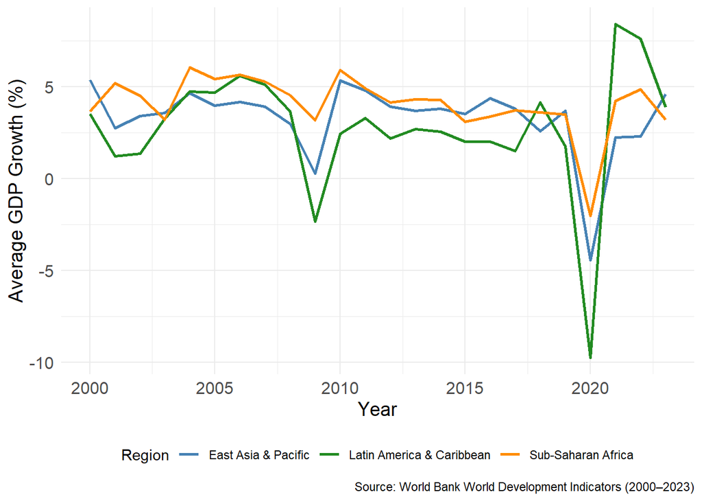

Variability in GDP Growth

The box plot below illustrates the distribution of GDP growth within each region, highlighting differences in economic stability across countries.

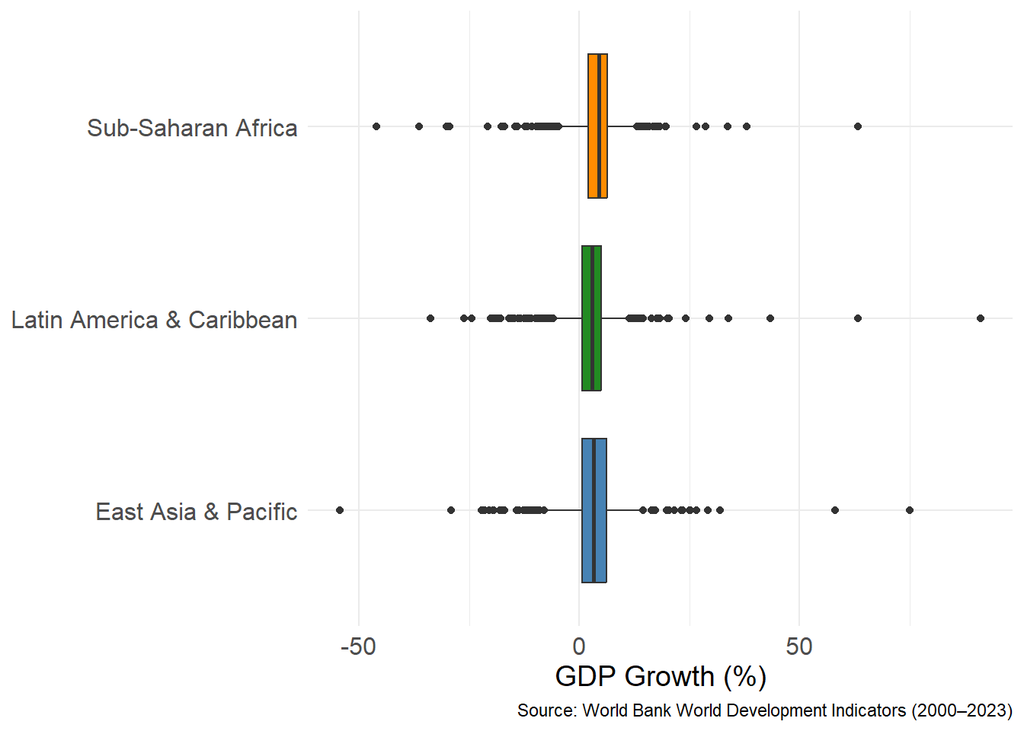